# Lab, Part 2: `Oscars` Data Analysis

## Import libraries and data

```r
library(tidyverse)
library(lubridate)
library(extrafont)

# load fonts - every session
loadfonts(device = "win", quiet = TRUE)

oscars <- read_csv('https://raw.githubusercontent.com/Cal-Poly-Advanced-R/Lab_1/master/Oscars-demographics-DFE.csv')
```

## Tidy data

Upon checking the data, we can see there aresome inconsistencies.

For `date_of_birth`:

- One person has `[1]` at the end of their birthday
- Some of the dates have years that are 2 digits, some 4. If we simply use `dmy()`, the years before 1969 will be put in the 21st century instead of the 20th.
- There is one person who only has a birth year listed.

```r
oscars$date_of_birth <- str_replace_all(oscars$date_of_birth," [1]","")   ## remove "[1]" from one of the obs

oscars <- oscars %>%
  # fix the date of birth

  mutate(date_of_birth = if_else(str_length(date_of_birth) > 11, str_sub(date_of_birth,1,11), date_of_birth)) %>%

  separate(date_of_birth, c("day","month","birthyear"), sep = "-", remove = FALSE) %>%   ## separate birthday components

  mutate(birthyear = case_when(str_length(birthyear) == 2 ~ paste0("19",birthyear),  ## add the century to the birth year
                               str_length(day) == 4 ~ day,  ## address the obs with only the year
                               TRUE ~ birthyear),

         dob = ymd(paste(birthyear,month,day,sep = " ")),  ## get the formatted birthday

         award_dt = ymd(paste(year_of_award,"Feb","1", sep = " ")),  ## format the exact award date

         ## calculate the person's age using the function age_years() from https://raw.githubusercontent.com/nzcoops/r-code/master/age_function.R
         age = age_years(as.Date(dob), as.Date(award_dt)),

         gender = case_when(award %in% c("Best Actor", "Best Supporting Actor") ~ 1,  ## gender indicator: M = 1, F = 0
                            award %in% c("Best Actress", "Best Supporting Actress") ~ 0,
                            TRUE ~ NA_real_),

         white = if_else(race_ethnicity == "White", 1, 0)) ## race = white indicator
```

## Warm-ups

1. Which movie(s) won the most unique “Big 5” awards?

```r
most_awards <- oscars %>%
  select(movie,award) %>%
  distinct() %>%   ## make sure there are no duplicates
  group_by(movie) %>%
  count(name = "awards") %>%  ## count the number of awards per movie
  ungroup() %>%
  filter(awards == max(awards))  ## only get the top movies with the most unique awards
```

| movie | awards |
| --- | --- |
| A Streetcar Named Desire | 3 |
| Cabaret | 3 |
| From Here to Eternity | 3 |
| Going My Way | 3 |
| Gone with the Wind | 3 |
| It Happened One Night | 3 |
| Kramer vs. Kramer | 3 |
| Million Dollar Baby | 3 |
| Mrs. Miniver | 3 |
| Network | 3 |
| On the Waterfront | 3 |
| Terms of Endearment | 3 |
| The Best Years of Our Lives | 3 |
| West Side Story | 3 |

2. Of all actresses who have won the Best Actress award, what are is the most common first name?

```r
common_name <- oscars %>%
  filter(award == "Best Actress") %>%
  distinct(person)%>%  ## make sure each actress is only counted once
  mutate(first_name = word(person,1)) %>%  ## get their first names
  group_by(first_name) %>%
  count() %>%  ## count the number of women with the same first name
  ungroup() %>%
  filter(n == max(n)) ## only output the most common
```

| first_name | n |
| --- | --- |
| Helen | 3 |

3. What US State, or non-US country, has produced the most Oscar winners (for the awards in this dataset)?

```r
common_birthplace <- oscars %>%
  select(person, birthplace) %>%
  distinct() %>%  ## make sure each person is only counted once
  group_by(birthplace) %>%
  count() %>%
  ungroup() %>%
  filter(n == max(n))
```

| birthplace | n |
| --- | --- |
| New York City | 27 |

The most common birthplace is **New York**, since New York City has produced the most Oscar winners.

## Age and Gender

**Prompt**: Create a linear model that explores how the typical age of acting award winners has changed over time, and how that effect is different for the two genders of awards.

```r
oscars_gender <- oscars %>%
  filter(award != "Best Director") %>%
  select(person,movie,award,year_of_award,gender,age,white) %>%
  distinct()  ## make sure not to get duplicates

lm(formula = age ~ year_of_award + gender, data = oscars_gender)
```

```
##
## Call:
## lm(formula = age ~ year_of_award + gender, data = oscars_gender)
##
## Coefficients:
##   (Intercept)  year_of_award         gender
##      -71.0100         0.0551         9.0873
```

If we look at a scatter plot of the `year_of_award` vs `age` and highlight them based on gender, we can see that it seems to be in line with the result of the linear model above. Females tend to be younger, and the age of the winners has been ever-so-slightly rising over the years.

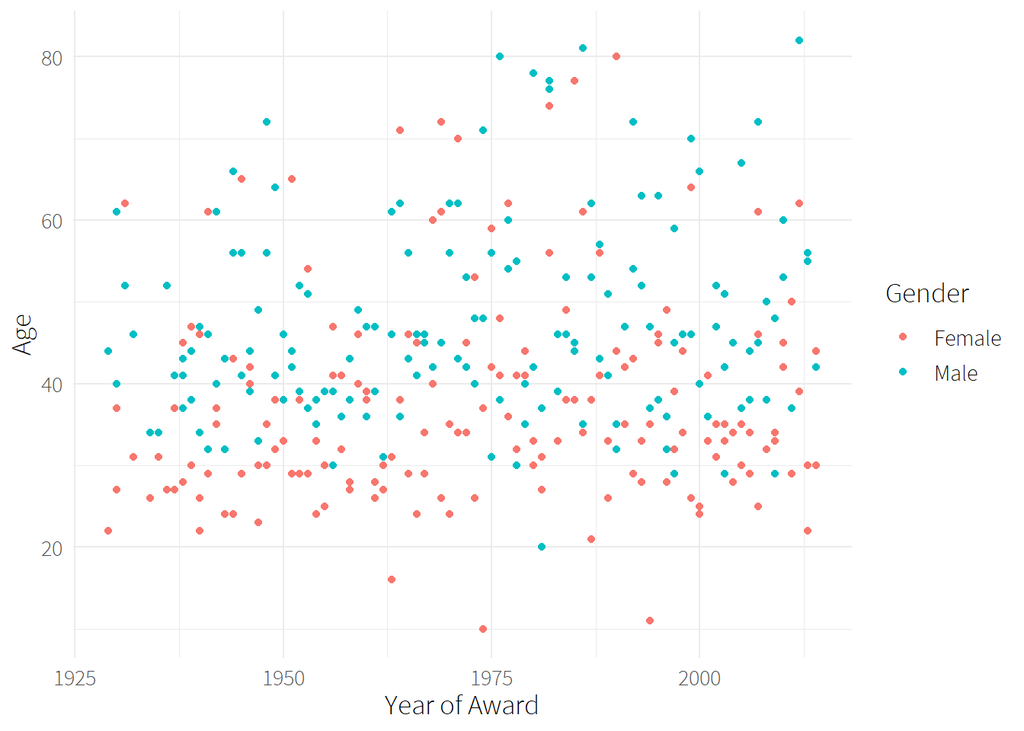